# snowfall_rescaling_testing_map2017

```python
import netCDF4 as nc
import pandas as pd
import os
import matplotlib.pyplot as plt
import numpy as np
from datetime import datetime
from datetime import timedelta
from scipy.stats import skew
from timeit import timeit
from skimage import io
```

```python
path_smrf = '/data/blizzard/tuolumne/devel/wy2016/wy2016_rerun_andrew_awsm_latedecay/data/data20151001_20161001/smrfOutputs/'
path_peak_swe = '/home/ernestotrujillo/Documents/Data/Tuolumne/Peak_SWE/'
path_topo = '/home/ernestotrujillo/Documents/Data/Tuolumne/Topo/'
precip_name = 'precip.nc'
percent_name = 'percent_snow.nc'
topo_name = 'tuolx_dem_50m.asc'
# File information below
```

## precip netCDF examples in (Snow Server)

### /data/blizzard/tuolumne/devel/wy2016/wy2016_rerun_andrew_awsm_latedecay/data/data20151001_20161001/smrfOutputs

# ncdump on the precip output from smrf shows:

## ncdump -h precip.nc

### dimensions:

```
time = UNLIMITED ; // (8785 currently)
y = 1339 ;
x = 1374 ;
```

### variables:

```
float time(time) ;
    time:units = "hours since 2015-10-01 00:00:00" ;
    time:calendar = "standard" ;
    time:time_zone = "utc" ;
    time:long_name = "time" ;
float y(y) ;
    y:units = "meters" ;
    y:description = "UTM, north south" ;
    y:long_name = "y coordinate" ;
float x(x) ;
    x:units = "meters" ;
    x:description = "UTM, east west" ;
    x:long_name = "x coordinate" ;
float precip(time, y, x) ;
    precip:module = "precip" ;
    precip:units = "mm" ;
    precip:long_name = "Precipitation mass" ;
```

### // global attributes:

```
    :_NCProperties = "version=1|netcdflibversion=4.4.1.1|hdf5libversion=1.8.18" ;
    string :Conventions = "CF-1.6" ;
    string :dateCreated = "2018-01-03 18:51:49" ;
    string :title = "Distirbuted Precipitation mass data from SMRF" ;
    string :history = "[2018-01-03 18:51:49] Create netCDF4 file" ;
    string :institution = "USDA Agricultural Research Service, Northwest Watershed Research Center" ;
    string :references = "Online documentation smrf.readthedocs.io; https://doi.org/10.1016/j.cageo.2017.08.016" ;
    string :source = "SMRF v0.3.0-94-g599f914" ;
```

}

## ncdump -h percent_snow.nc

### dimensions:

```
time = UNLIMITED ; // (8785 currently)
y = 1339 ;
x = 1374 ;
```

### variables:

```
float time(time) ;
    time:units = "hours since 2015-10-01 00:00:00" ;
    time:calendar = "standard" ;
    time:time_zone = "utc" ;
    time:long_name = "time" ;
float y(y) ;
    y:units = "meters" ;
    y:description = "UTM, north south" ;
    y:long_name = "y coordinate" ;
float x(x) ;
    x:units = "meters" ;
    x:description = "UTM, east west" ;
    x:long_name = "x coordinate" ;
float percent_snow(time, y, x) ;
    percent_snow:module = "precip" ;
    percent_snow:units = "%" ;
    percent_snow:long_name = "Percent of precipitation as snow" ;
```

### // global attributes:

```
    :_NCProperties = "version=1|netcdflibversion=4.4.1.1|hdf5libversion=1.8.18" ;
    string :Conventions = "CF-1.6" ;
    string :dateCreated = "2018-01-03 18:51:49" ;
    string :title = "Distirbuted Percent of precipitation as snow data from SMRF" ;
    string :history = "[2018-01-03 18:51:49] Create netCDF4 file" ;
    string :institution = "USDA Agricultural Research Service, Northwest Watershed Research Center" ;
    string :references = "Online documentation smrf.readthedocs.io; https://doi.org/10.1016/j.cageo.2017.08.016" ;
    string :source = "SMRF v0.3.0-94-g599f914" ;
```

}

```python
def snowfall_rescaling_timestep(precip_np, snow_fraction_np, snow_map_np):
    '''
    Parameters:
        Precip_np: 2D numpy array with the precipitation field for a given timestep
        snow_fraction_np: 2D numpy array with the snow fraction (0.0 - 1.0) field for a given timestep
        snow_map_np: 2D numpy array with the snow field to use for the rescaling
            of solid precip

        All input grids must have the same projection, extent, and resolution

    Return:
        precip_np_out: 2D numpy array with rescaled total precipitation (rain + snow) mass
                       for the time interval
        snow_fraction_np_out: 2D numpy array with the snow fraction (0.0 - 1.0)

    Note: This function assumes that there are not no-data flags, just values with a range between 0-inf
    '''

    precip_np_out = precip_np.copy()
    snow_fraction_np_out = snow_fraction_np.copy()
    return_flag = False # True if rescaled

    if np.sum(snow_fraction_np) > 0:

        snowfall = precip_np * snow_fraction_np
        rainfall = precip_np - snowfall
        # The rainfall matrix does not change

        # Select the area that has a snowfall value for the time step
        snow_map_select = np.zeros(np.shape(snowfall), dtype = float)
        snow_map_select[(snowfall > 0) & (snow_map_np > 0)] = snow_map_np[(snowfall > 0) & (snow_map_np > 0)]
        # With the lines above we make sure that we only select the area with
        # positive values on both.
        # Also, this way we mantain the no-data flags in the original NetCDF4 file
        # remember both grids must have the same extent, dim., res.

        if np.sum(snow_map_select > 0) > 0: # won't enter if no area intersect between snowfall and snow_map_np

            mean_snowfall = np.mean(snowfall[snow_map_select > 0])
            # we use snow_map_select because we want the area with positive values in both snowfall and snow_map_np
            mean_snow_map = np.mean(snow_map_select[snow_map_select > 0]) # non-zero mean

            snowfall_rescaled = snowfall.copy()
            snowfall_rescaled[snow_map_select > 0] = snow_map_select[snow_map_select > 0]  * mean_snowfall / mean_snow_map
            # The line above only modifies areas with positive values in snow_map_select
            # which means it only modifies the areas where we know the snow distribution and we have snowfall

            # output
            precip_np_out = rainfall + snowfall_rescaled # only the snowfall was modified
            snow_fraction_np_out[snowfall_rescaled > 0] = snowfall_rescaled[snowfall_rescaled > 0] / precip_np_out[snowfall_rescaled > 0]
            return_flag = True

    return precip_np_out, snow_fraction_np_out, return_flag
```

```python
# Function to rescale a full NetCDF4 precip and snow_percent (which should be fraction, nor percent) files
# using the 'snowfall_rescaling_timestep' function above

def snowfall_rescaling(precip_path, percent_snow_path, precip_field, snow_percent_field, snow_map_np):
    '''
    Parameters:
        precip_path: full path of NetCDF4 file with the precipitation information
        percent_snow_path: full path of NetCDF4 file with the snow fraction information
        precip_field: name of the precipitation field in the nc file (str)
        snow_percent_field: name of the field containing the
            percentage of precip in the form of snow (str)

        All input grids must have the same projection, extent, and resolution

    Return:
        precip_np_out: 3D numpy array with total precipitation (rain + snow) mass per time interval
        snow_fraction_np_out: 3D numpy array with fraction (0-1)

    Note: Assuming that there are not no-data flags, just values with a range between 0-inf
    '''

    precip_nc = nc.Dataset(precip_path)
    percent_nc = nc.Dataset(percent_snow_path)

    precip_rescaled = np.zeros(precip_nc.variables[precip_field].shape, dtype = float)
    percent_rescaled = np.zeros(percent_nc.variables[snow_percent_field].shape, dtype = float)
    rescaling_flag = np.empty(precip_nc.variables[precip_field].shape[0], dtype = bool)

    for i_time in range(len(rescaling_flag)):

        precip_rescaled[i_time, :, :], percent_rescaled[i_time, :, :], rescaling_flag[i_time] = \
        snowfall_rescaling_timestep(precip_nc.variables[precip_field][i_time, :, :],
                                    percent_nc.variables[snow_percent_field][i_time, :, :],
                                    snow_map_np)

    return precip_rescaled, percent_rescaled, rescaling_flag
```

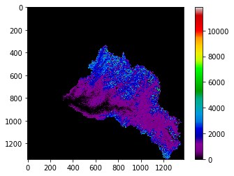

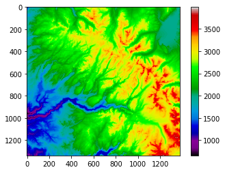

```python
# Test of the functions

# Option to change the test map and the year suffix for plots and file naming
# CHANGE HERE FOR DIFFERENT TESTS

# peak_swe_map_test = np.loadtxt(path_peak_swe + '2016_pixelpeak_swe.asc', skiprows = 6)
# peak_swe_map_test = io.imread(path_peak_swe + 'TB20160416_iSnobal_SWE_50p0m.tif')
peak_swe_map_test = np.loadtxt(path_peak_swe + '2017_pixelpeak_swe.asc', skiprows = 6)

year_test = '2016'

title_plots = year_test + ' - Based on pixel-based peak SWE'
swe_map_title = '2017_pixelpeak_swe.asc'

stats_filename_full = 'stats_test_full_' + year_test + '_2017pixelpeak'
stats_filename_tuolumne = 'stats_test_tuolumne_' + year_test + '_2017pixelpeak'
date_zero = pd.to_datetime('2015-10-01 00:00:00')
# -----------------------------------------------------------------------------

h_img = plt.imshow(peak_swe_map_test, cmap='nipy_spectral')
plt.colorbar()
plt.show()

topo_full_domain = np.loadtxt(path_topo + topo_name, skiprows = 6)

h_img = plt.imshow(topo_full_domain, cmap='nipy_spectral')
plt.colorbar()
plt.show()
```

```python
# Test of the 'snowfall_rescaling_timestep' function

precip_nc_test = nc.Dataset(path_smrf + precip_name)
percent_nc_test = nc.Dataset(path_smrf + percent_name)

# # Uncomment to perform a direct test of the data and functions

# snowfall_flag_test = np.empty(precip_nc_test.variables['time'].shape, dtype = bool)
# snowfall_flag_test[:] = False

# for i_time in range(len(snowfall_flag_test)):

#     if np.sum(percent_nc_test.variables['percent_snow'][i_time, :, :]) > 0:

#         snowfall_flag_test[i_time] = True

# print('The number of timesteps with snowfall is {}'.format(np.sum(snowfall_flag_test)))

# precip_rescaled_test = np.zeros(precip_nc_test.variables['precip'].shape, dtype = float)
# percent_rescaled_test = np.zeros(percent_nc_test.variables['percent_snow'].shape, dtype = float)
# rescaling_flag_test = np.empty(precip_nc_test.variables['time'].shape, dtype = bool)
# rescaling_flag_test[:] = False

# for i_time in range(len(precip_nc_test.variables['time'])):

#     precip_rescaled_test[i_time, :, :], percent_rescaled_test[i_time, :, :], rescaling_flag_test[i_time] = \
#     snowfall_rescaling_timestep(precip_nc_test.variables['precip'][i_time, :, :], percent_nc_test.variables['percent_snow'][i_time, :, :], peak_swe_map_test)

# print('The number of timesteps with rescaled snowfall is {}'.format(np.sum(rescaling_flag_test)))
# print('This means that snowfall ocurred only outside of the area with\nprior snow distribution information {} timesteps'
#       .format(np.sum(snowfall_flag_test) - np.sum(rescaling_flag_test)))
```

```python
# Test of the 'snowfall_rescaling' function
# First, obtain the time that it takes to run a year of hourly Tuolumne precip
# and generate the tuple of the output

# %timeit test_tuple = snowfall_rescaling(path_smrf + precip_name, path_smrf + percent_name, 'precip', 'percent_snow', pixelpeak_swe_2016)
# run on snow server showed an average time of 6 mins for 1 year of hourly precip (7 runs)
test_tuple = snowfall_rescaling(path_smrf + precip_name, path_smrf + percent_name, 'precip', 'percent_snow', peak_swe_map_test)
```

```python
# First, are we conserving mass? from before to after rescaling
# This cell contains the code to generate the statistics
# of the fields generated in smrf and with the rescaling interpolation

mask_snowy_tuolumne = peak_swe_map_test > 0

date_index_precip = pd.date_range(date_zero,
                                  date_zero
                                  + timedelta(hours = len(precip_nc_test.variables['time']) - 1),
                                  freq='H')

stats_test = pd.DataFrame(data = np.zeros((len(date_index_precip), 14), dtype = float),
                         index = date_index_precip,
                         columns = ['precip_smrf', 'snowfall_smrf', 'mean_smrf', 'stdev_smrf', 'skew_smrf', 'min_smrf', 'max_smrf',
                                    'precip_rescaled', 'snowfall_rescaled', 'mean_rescaled', 'stdev_rescaled', 'skew_rescaled', 'min_rescaled', 'max_rescaled'])

stats_test_tuolumne = pd.DataFrame(data = np.zeros((len(date_index_precip), 14), dtype = float),
                         index = date_index_precip,
                         columns = ['sum_precip_smrf', 'sum_snowfall_smrf', 'mean_snowfall_smrf', 'stdev_snowfall_smrf',
                                    'skew_snowfall_smrf', 'min_snowfall_smrf', 'max_snowfall_smrf',
                                    'sum_precip_rescaled', 'sum_snowfall_rescaled', 'mean_snowfall_rescaled', 'stdev_snowfall_rescaled',
                                    'skew_snowfall_rescaled', 'min_snowfall_rescaled', 'max_snowfall_rescaled'])

for i_time in range(len(date_index_precip)):

    # Full domain analysis ------------------------------------------------------------

    # SMRF data
    precip_smrf_aux = precip_nc_test.variables['precip'][i_time, :, :]
    snowfall_smrf_aux = precip_nc_test.variables['precip'][i_time, :, :] * percent_nc_test.variables['percent_snow'][i_time, :, :]

    stats_test.loc[date_index_precip[i_time], 'sum_precip_smrf'] = np.sum(precip_smrf_aux)
    stats_test.loc[date_index_precip[i_time], 'sum_snowfall_smrf'] = np.sum(snowfall_smrf_aux)
    stats_test.loc[date_index_precip[i_time], 'mean_snowfall_smrf'] = np.mean(snowfall_smrf_aux)
    stats_test.loc[date_index_precip[i_time], 'stdev_snowfall_smrf'] = np.std(snowfall_smrf_aux)
    stats_test.loc[date_index_precip[i_time], 'skew_snowfall_smrf'] = skew(snowfall_smrf_aux.flatten())
    stats_test.loc[date_index_precip[i_time], 'min_snowfall_smrf'] = np.amin(snowfall_smrf_aux)
    stats_test.loc[date_index_precip[i_time], 'max_snowfall_smrf'] = np.amax(snowfall_smrf_aux)

    # Rescaled data
    precip_rescaled_aux = test_tuple[0][i_time, :, :]
    snowfall_rescaled_aux = test_tuple[0][i_time, :, :] * test_tuple[1][i_time, :, :]

    stats_test.loc[date_index_precip[i_time], 'sum_precip_rescaled'] = np.sum(precip_rescaled_aux)
    stats_test.loc[date_index_precip[i_time], 'sum_snowfall_rescaled'] = np.sum(snowfall_rescaled_aux)
    stats_test.loc[date_index_precip[i_time], 'mean_snowfall_rescaled'] = np.mean(snowfall_rescaled_aux)
    stats_test.loc[date_index_precip[i_time], 'stdev_snowfall_rescaled'] = np.std(snowfall_rescaled_aux)
    stats_test.loc[date_index_precip[i_time], 'skew_snowfall_rescaled'] = skew(snowfall_rescaled_aux.flatten())
    stats_test.loc[date_index_precip[i_time], 'min_snowfall_rescaled'] = np.amin(snowfall_rescaled_aux)
    stats_test.loc[date_index_precip[i_time], 'max_snowfall_rescaled'] = np.amax(snowfall_rescaled_aux)

    # Tuolumne domain analysis ------------------------------------------------------------

    # SMRF data
    stats_test_tuolumne.loc[date_index_precip[i_time], 'sum_precip_smrf'] = np.sum(precip_smrf_aux[mask_snowy_tuolumne])
    stats_test_tuolumne.loc[date_index_precip[i_time], 'sum_snowfall_smrf'] = np.sum(snowfall_smrf_aux[mask_snowy_tuolumne])
    stats_test_tuolumne.loc[date_index_precip[i_time], 'mean_snowfall_smrf'] = np.mean(snowfall_smrf_aux[mask_snowy_tuolumne])
    stats_test_tuolumne.loc[date_index_precip[i_time], 'stdev_snowfall_smrf'] = np.std(snowfall_smrf_aux[mask_snowy_tuolumne])
    stats_test_tuolumne.loc[date_index_precip[i_time], 'skew_snowfall_smrf'] = skew(snowfall_smrf_aux[mask_snowy_tuolumne].flatten())
    stats_test_tuolumne.loc[date_index_precip[i_time], 'min_snowfall_smrf'] = np.amin(snowfall_smrf_aux[mask_snowy_tuolumne])
    stats_test_tuolumne.loc[date_index_precip[i_time], 'max_snowfall_smrf'] = np.amax(snowfall_smrf_aux[mask_snowy_tuolumne])

    # Rescaled data
    stats_test_tuolumne.loc[date_index_precip[i_time], 'sum_precip_rescaled'] = np.sum(precip_rescaled_aux[mask_snowy_tuolumne])
    stats_test_tuolumne.loc[date_index_precip[i_time], 'sum_snowfall_rescaled'] = np.sum(snowfall_rescaled_aux[mask_snowy_tuolumne])
    stats_test_tuolumne.loc[date_index_precip[i_time], 'mean_snowfall_rescaled'] = np.mean(snowfall_rescaled_aux[mask_snowy_tuolumne])
    stats_test_tuolumne.loc[date_index_precip[i_time], 'stdev_snowfall_rescaled'] = np.std(snowfall_rescaled_aux[mask_snowy_tuolumne])
    stats_test_tuolumne.loc[date_index_precip[i_time], 'skew_snowfall_rescaled'] = skew(snowfall_rescaled_aux[mask_snowy_tuolumne].flatten())
    stats_test_tuolumne.loc[date_index_precip[i_time], 'min_snowfall_rescaled'] = np.amin(snowfall_rescaled_aux[mask_snowy_tuolumne])
    stats_test_tuolumne.loc[date_index_precip[i_time], 'max_snowfall_rescaled'] = np.amax(snowfall_rescaled_aux[mask_snowy_tuolumne])

print(stats_test_tuolumne.iloc[3, :])
```

```
sum_precip_smrf            259032.734375
sum_snowfall_smrf            1888.480225
mean_snowfall_smrf              0.004116
stdev_snowfall_smrf             0.028624
skew_snowfall_smrf              9.010274
min_snowfall_smrf               0.000000
max_snowfall_smrf               0.522102
sum_precip_rescaled        259032.725230
sum_snowfall_rescaled        1888.480464
mean_snowfall_rescaled          0.004116
stdev_snowfall_rescaled         0.029535
skew_snowfall_rescaled         10.055073
min_snowfall_rescaled           0.000000
max_snowfall_rescaled           0.768424
Name: 2015-10-01 03:00:00, dtype: float64
```

```python
stats_test.to_csv('./CSV_files/' + stats_filename_full + '.csv')
stats_test_tuolumne.to_csv('./CSV_files/' + stats_filename_tuolumne + '.csv')
```

```python
print(stats_filename_full)
print(stats_filename_tuolumne)
```

```
stats_test_full_2016_2017pixelpeak
stats_test_tuolumne_2016_2017pixelpeak
```

```python
# # uncomment if the previous stat analysis cell is to be skipped
# stats_test = pd.read_csv('./CSV_files/' + stats_filename_full + '.csv', index_col = 0, parse_dates = True)
# stats_test_tuolumne = pd.read_csv('./CSV_files/' + stats_filename_tuolumne + '.csv', index_col = 0, parse_dates = True)
```

```python
# print(stats_test_tuolumne)
```

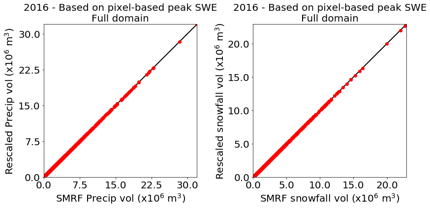

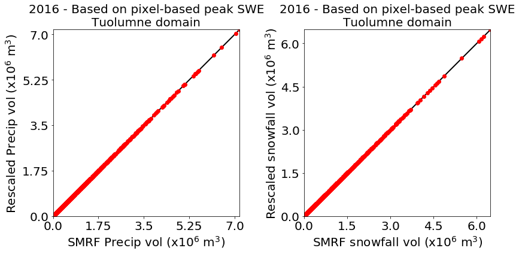

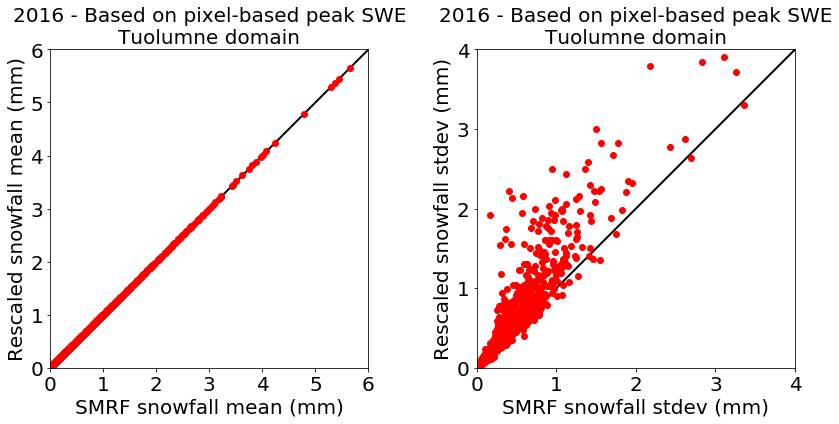

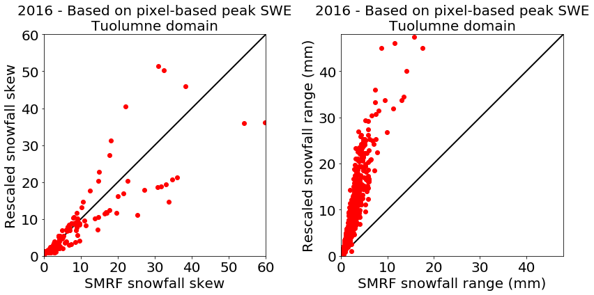

```python
# Plot scatter plots of results
# Things to look for:
# 1- There should not be points with 0 for one of the axes and positive values for the other
# 2- Points should be aligned along the one-to-one line

fs_axes = 20
fs_title = 20
fs_labels = 20


# Plot 1 *******************************************************
# Full domain

# Precipitation ------------------------------------------------
plt.figure(figsize = (12, 6))
ax1 = plt.subplot(1, 2, 1)

x_max = max(stats_test.max(axis = 0)['sum_precip_smrf'], stats_test.max(axis = 0)['sum_precip_rescaled']) * 50 * 50 * 1e-3 # should be in m3

ax1.plot([0, x_max], [0, x_max], '-k', linewidth = 2, zorder = 0)
h_scatter = plt.scatter(stats_test['sum_precip_smrf'].values * 50 * 50 * 1e-3, stats_test['sum_precip_rescaled'].values * 50 * 50 * 1e-3)
plt.setp(h_scatter, color = 'r')
ax1.set_xlabel('SMRF Precip vol (x10$^6$ m$^3$)', fontsize = fs_labels)
ax1.set_ylabel('Rescaled Precip vol (x10$^6$ m$^3$)', fontsize = fs_labels)
ax1.set_title(title_plots + '\nFull domain', fontsize = fs_title)

ticks_x = list(range(0, int(x_max), int(round(x_max/1e7) * 1e7 / 4)))
ticklabels_x = [str(tick_x * 1e-6) for tick_x in ticks_x]
ax1.set_xticks(ticks_x)
ax1.set_xticklabels(ticklabels_x)
ax1.set_yticks(ticks_x)
ax1.set_yticklabels(ticklabels_x)
plt.tick_params(axis='both', which='major', labelsize=fs_labels)

ax1.set_xlim([0, x_max])
ax1.set_ylim([0, x_max])
ax1.set_aspect('equal', 'box')
plt.tight_layout()

# Snowfall ---------------------------------------------------------
ax2 = plt.subplot(1, 2, 2)

x_max = max(stats_test.max(axis = 0)['sum_snowfall_smrf'], stats_test.max(axis = 0)['sum_snowfall_rescaled']) * 50 * 50 * 1e-3 # should be in m3

ax2.plot([0, x_max], [0, x_max], '-k', linewidth = 2, zorder = 0)
h_scatter = plt.scatter(stats_test['sum_snowfall_smrf'].values * 50 * 50 * 1e-3, stats_test['sum_snowfall_rescaled'].values * 50 * 50 * 1e-3)
plt.setp(h_scatter, color = 'r')
ax2.set_xlabel('SMRF snowfall vol (x10$^6$ m$^3$)', fontsize = fs_labels)
ax2.set_ylabel('Rescaled snowfall vol (x10$^6$ m$^3$)', fontsize = fs_labels)
ax2.set_title(title_plots + '\nFull domain', fontsize = fs_title)

ticks_x = list(range(0, int(x_max), int(round(x_max/1e7) * 1e7 / 4)))
ticklabels_x = [str(tick_x * 1e-6) for tick_x in ticks_x]
ax2.set_xticks(ticks_x)
ax2.set_xticklabels(ticklabels_x)
ax2.set_yticks(ticks_x)
ax2.set_yticklabels(ticklabels_x)
plt.tick_params(axis='both', which='major', labelsize=fs_labels)

ax2.set_xlim([0, x_max])
ax2.set_ylim([0, x_max])
ax2.set_aspect('equal', 'box')
plt.tight_layout()


# Plot 2 *******************************************************
# Area in Tuolumne with LIDAR info

# Precipitation ------------------------------------------------
plt.figure(figsize = (12, 6))
ax1 = plt.subplot(1, 2, 1)

x_max = max(stats_test_tuolumne.max(axis = 0)['sum_precip_smrf'], stats_test_tuolumne.max(axis = 0)['sum_precip_rescaled']) * 50 * 50 * 1e-3 # should be in m3

ax1.plot([0, x_max], [0, x_max], '-k', linewidth = 2, zorder = 0)
h_scatter = plt.scatter(stats_test_tuolumne['sum_precip_smrf'].values * 50 * 50 * 1e-3, stats_test_tuolumne['sum_precip_rescaled'].values * 50 * 50 * 1e-3)
plt.setp(h_scatter, color = 'r')
ax1.set_xlabel('SMRF Precip vol (x10$^6$ m$^3$)', fontsize = fs_labels)
ax1.set_ylabel('Rescaled Precip vol (x10$^6$ m$^3$)', fontsize = fs_labels)
ax1.set_title(title_plots + '\nTuolumne domain', fontsize = fs_title)

ticks_x = list(range(0, int(x_max), int(round(x_max/1e6) * 1e6 / 4)))
ticklabels_x = [str(tick_x * 1e-6) for tick_x in ticks_x]
ax1.set_xticks(ticks_x)
ax1.set_xticklabels(ticklabels_x)
ax1.set_yticks(ticks_x)
ax1.set_yticklabels(ticklabels_x)
plt.tick_params(axis='both', which='major', labelsize=fs_labels)

ax1.set_xlim([0, x_max])
ax1.set_ylim([0, x_max])
ax1.set_aspect('equal', 'box')
plt.tight_layout()

# Snowfall ---------------------------------------------------------
ax2 = plt.subplot(1, 2, 2)

x_max = max(stats_test_tuolumne.max(axis = 0)['sum_snowfall_smrf'], stats_test_tuolumne.max(axis = 0)['sum_snowfall_rescaled']) * 50 * 50 * 1e-3 # should be in m3

ax2.plot([0, x_max], [0, x_max], '-k', linewidth = 2, zorder = 0)
h_scatter = plt.scatter(stats_test_tuolumne['sum_snowfall_smrf'].values * 50 * 50 * 1e-3, stats_test_tuolumne['sum_snowfall_rescaled'].values * 50 * 50 * 1e-3)
plt.setp(h_scatter, color = 'r')
ax2.set_xlabel('SMRF snowfall vol (x10$^6$ m$^3$)', fontsize = fs_labels)
ax2.set_ylabel('Rescaled snowfall vol (x10$^6$ m$^3$)', fontsize = fs_labels)
ax2.set_title(title_plots + '\nTuolumne domain', fontsize = fs_title)

ticks_x = list(range(0, int(x_max), int(round(x_max/1e6) * 1e6 / 4)))
ticklabels_x = [str(tick_x * 1e-6) for tick_x in ticks_x]
ax2.set_xticks(ticks_x)
ax2.set_xticklabels(ticklabels_x)
ax2.set_yticks(ticks_x)
ax2.set_yticklabels(ticklabels_x)
plt.tick_params(axis='both', which='major', labelsize=fs_labels)

ax2.set_xlim([0, x_max])
ax2.set_ylim([0, x_max])
ax2.set_aspect('equal', 'box')
plt.tight_layout()


# Plot 3 *******************************************************
# Area in Tuolumne with LIDAR info (mean)

# Snowfall mean ------------------------------------------------
plt.figure(figsize = (12, 6))
ax1 = plt.subplot(1, 2, 1)

x_max = np.ceil(max(stats_test_tuolumne.max(axis = 0)['mean_snowfall_smrf'], stats_test_tuolumne.max(axis = 0)['mean_snowfall_rescaled'])) # should be in mm

ax1.plot([0, x_max], [0, x_max], '-k', linewidth = 2, zorder = 0)
h_scatter = plt.scatter(stats_test_tuolumne['mean_snowfall_smrf'].values, stats_test_tuolumne['mean_snowfall_rescaled'].values)
plt.setp(h_scatter, color = 'r')
ax1.set_xlabel('SMRF snowfall mean (mm)', fontsize = fs_labels)
ax1.set_ylabel('Rescaled snowfall mean (mm)', fontsize = fs_labels)
ax1.set_title(title_plots + '\nTuolumne domain', fontsize = fs_title)

ticks_x = list(range(int(x_max+1)))
ticklabels_x = [str(tick_x) for tick_x in ticks_x]
ax1.set_xticks(ticks_x)
ax1.set_xticklabels(ticklabels_x)
ax1.set_yticks(ticks_x)
ax1.set_yticklabels(ticklabels_x)
plt.tick_params(axis='both', which='major', labelsize=fs_labels)

ax1.set_xlim([0, x_max])
ax1.set_ylim([0, x_max])
ax1.set_aspect('equal', 'box')
plt.tight_layout()

# Snowfall stdev ---------------------------------------------------------
ax2 = plt.subplot(1, 2, 2)

x_max = np.ceil(max(stats_test_tuolumne.max(axis = 0)['stdev_snowfall_smrf'], stats_test_tuolumne.max(axis = 0)['stdev_snowfall_rescaled']))  # should be in mm

ax2.plot([0, x_max], [0, x_max], '-k', linewidth = 2, zorder = 0)
h_scatter = plt.scatter(stats_test_tuolumne['stdev_snowfall_smrf'].values, stats_test_tuolumne['stdev_snowfall_rescaled'].values)
plt.setp(h_scatter, color = 'r')
ax2.set_xlabel('SMRF snowfall stdev (mm)', fontsize = fs_labels)
ax2.set_ylabel('Rescaled snowfall stdev (mm)', fontsize = fs_labels)
ax2.set_title(title_plots + '\nTuolumne domain', fontsize = fs_title)

ticks_x = list(range(int(x_max+1)))
ticklabels_x = [str(tick_x) for tick_x in ticks_x]
ax2.set_xticks(ticks_x)
ax2.set_xticklabels(ticklabels_x)
ax2.set_yticks(ticks_x)
ax2.set_yticklabels(ticklabels_x)
plt.tick_params(axis='both', which='major', labelsize=fs_labels)

ax2.set_xlim([0, x_max])
ax2.set_ylim([0, x_max])
ax2.set_aspect('equal', 'box')
plt.tight_layout()


# Plot 4 *******************************************************
# Area in Tuolumne with LIDAR info (skew/range)

# Snowfall mean ------------------------------------------------
plt.figure(figsize = (12, 6))
ax1 = plt.subplot(1, 2, 1)

x_max = np.ceil(max(stats_test_tuolumne.max(axis = 0)['skew_snowfall_smrf'], stats_test_tuolumne.max(axis = 0)['skew_snowfall_rescaled']))

ax1.plot([0, x_max], [0, x_max], '-k', linewidth = 2, zorder = 0)
h_scatter = plt.scatter(stats_test_tuolumne['skew_snowfall_smrf'].values, stats_test_tuolumne['skew_snowfall_rescaled'].values)
plt.setp(h_scatter, color = 'r')
ax1.set_xlabel('SMRF snowfall skew', fontsize = fs_labels)
ax1.set_ylabel('Rescaled snowfall skew', fontsize = fs_labels)
ax1.set_title(title_plots + '\nTuolumne domain', fontsize = fs_title)

ticks_x = list(range(0, int(x_max)+10, 10))
ticklabels_x = [str(tick_x) for tick_x in ticks_x]
ax1.set_xticks(ticks_x)
ax1.set_xticklabels(ticklabels_x)
ax1.set_yticks(ticks_x)
ax1.set_yticklabels(ticklabels_x)
plt.tick_params(axis='both', which='major', labelsize=fs_labels)

ax1.set_xlim([0, x_max])
ax1.set_ylim([0, x_max])
ax1.set_aspect('equal', 'box')
plt.tight_layout()

# Snowfall stdev ---------------------------------------------------------
ax2 = plt.subplot(1, 2, 2)

smrf_snow_range_tuolumne = stats_test_tuolumne['max_snowfall_smrf'] - stats_test_tuolumne['min_snowfall_smrf']
rescaled_snow_range_tuolumne = stats_test_tuolumne['max_snowfall_rescaled'] - stats_test_tuolumne['min_snowfall_rescaled']
x_max = np.ceil(max(max(smrf_snow_range_tuolumne), max(rescaled_snow_range_tuolumne)))

ax2.plot([0, x_max], [0, x_max], '-k', linewidth = 2, zorder = 0)
h_scatter = plt.scatter(smrf_snow_range_tuolumne, rescaled_snow_range_tuolumne)
plt.setp(h_scatter, color = 'r')
ax2.set_xlabel('SMRF snowfall range (mm)', fontsize = fs_labels)
ax2.set_ylabel('Rescaled snowfall range (mm)', fontsize = fs_labels)
ax2.set_title(title_plots + '\nTuolumne domain', fontsize = fs_title)

ticks_x = list(range(0, int(x_max)+10, 10))
ticklabels_x = [str(tick_x) for tick_x in ticks_x]
ax2.set_xticks(ticks_x)
ax2.set_xticklabels(ticklabels_x)
ax2.set_yticks(ticks_x)
ax2.set_yticklabels(ticklabels_x)
plt.tick_params(axis='both', which='major', labelsize=fs_labels)

ax2.set_xlim([0, x_max])
ax2.set_ylim([0, x_max])
ax2.set_aspect('equal', 'box')
plt.tight_layout()
```

# What do these plots show:

- Mass/volume is preserved both at the full domain and Tuolumne basin scales
- The stdev inside the Tuolumne domain, increases generally, but this is not a feature that occurs over all timesteps
- The skewness is more scattered with skewness value and all values are positive inside the Tuolumne domain
- The range increases markedly with the rescaling methodology within the Tuolumne domain

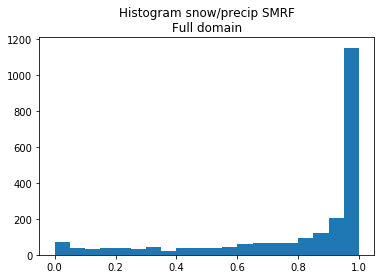

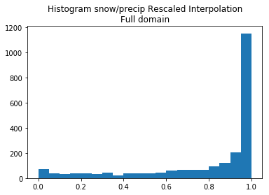

```python
plt.figure()
plt.hist(stats_test['sum_snowfall_smrf'].values[stats_test['sum_snowfall_smrf'].values > 0]
         / stats_test['sum_precip_smrf'].values[stats_test['sum_snowfall_smrf'].values > 0] , bins=20)  # arguments are passed to np.histogram
plt.title("Histogram snow/precip SMRF\nFull domain")
plt.show()

plt.figure()
plt.hist(stats_test['sum_snowfall_rescaled'].values[stats_test['sum_snowfall_rescaled'].values > 0]
         / stats_test['sum_precip_rescaled'].values[stats_test['sum_snowfall_rescaled'].values > 0] , bins=20)  # arguments are passed to np.histogram
plt.title("Histogram snow/precip Rescaled Interpolation\nFull domain")
plt.show()
```

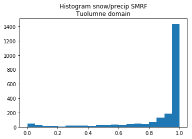

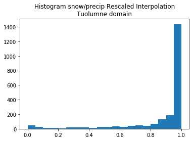

```python
plt.figure()
plt.hist(stats_test_tuolumne['sum_snowfall_smrf'].values[stats_test_tuolumne['sum_snowfall_smrf'].values > 0]
         / stats_test_tuolumne['sum_precip_smrf'].values[stats_test_tuolumne['sum_snowfall_smrf'].values > 0] , bins=20)  # arguments are passed to np.histogram
plt.title("Histogram snow/precip SMRF\nTuolumne domain")
plt.show()

plt.figure()
plt.hist(stats_test_tuolumne['sum_snowfall_rescaled'].values[stats_test_tuolumne['sum_snowfall_rescaled'].values > 0]
         / stats_test_tuolumne['sum_precip_rescaled'].values[stats_test_tuolumne['sum_snowfall_rescaled'].values > 0] , bins=20)  # arguments are passed to np.histogram
plt.title("Histogram snow/precip Rescaled Interpolation\nTuolumne domain")
plt.show()
```

# What do these plots show?

- Precip/snow ratios are within the correct range (0.0 - 1.0) (ratios are per basin totals, not pixel-by-pixel)
- The number of values between 0.9-1.0 increases within the Tuolumne domain
- The ratios obtained for basin volumens are the same with both methodologies (as they should), indicating that rain/snow aportionments are preserved at the basin and full domain scales.

```python
max(stats_test_tuolumne['skew_snowfall_rescaled'])
```

```
51.43216635307336
```

# Now an analysis of the differences in the elevational snow distribution with and without the precipitation rescaling methodology

### Here, I will use the deepest storm in 2016

```python
mask_snowy_tuolumne = peak_swe_map_test > 0

# precip_nc_test = nc.Dataset(path_smrf + precip_name)
# percent_nc_test = nc.Dataset(path_smrf + percent_name)


# get the row of max value
index_max_snowfall = stats_test_tuolumne['sum_snowfall_smrf'].idxmax() # This is a Datetime index (loc)
iloc_max_snowfall = stats_test_tuolumne.index.get_loc(index_max_snowfall) # row number (iloc) index
print(index_max_snowfall, iloc_max_snowfall)

# Elevation bands definition
topo_tuolumne = topo_full_domain[mask_snowy_tuolumne]

band_width = 250
min_limit = np.floor(np.min(topo_tuolumne) / band_width) * band_width
max_limit = np.ceil(np.max(topo_tuolumne) / band_width) * band_width
print(min_limit, max_limit)

lower_limits = list(range(int(min_limit), int(max_limit), band_width))
print(lower_limits)

# Elevational dataframe initiation
snowfall_tuolumne_elev_comparison = pd.DataFrame(data = np.zeros((len(lower_limits), 10), dtype = float),
                                     index = lower_limits,
                                     columns = ['mean_smrf', 'stdev_smrf', 'min_smrf', 'max_smrf', 'range_smrf',
                                                'mean_rescaled', 'stdev_rescaled', 'min_rescaled', 'max_rescaled', 'range_rescaled']
                                                )

# Full domain storm data ------------------------------------------------------------

# SMRF data
precip_smrf_aux = precip_nc_test.variables['precip'][iloc_max_snowfall, :, :]
snowfall_smrf_aux = precip_nc_test.variables['precip'][iloc_max_snowfall, :, :] * percent_nc_test.variables['percent_snow'][iloc_max_snowfall, :, :]

# Rescaled data
precip_rescaled_aux = test_tuple[0][iloc_max_snowfall, :, :]
snowfall_rescaled_aux = test_tuple[0][iloc_max_snowfall, :, :] * test_tuple[1][iloc_max_snowfall, :, :]

# Tuolumne domain storm data ------------------------------------------------------------
precip_smrf_aux_tuolumne = precip_smrf_aux[mask_snowy_tuolumne]
snowfall_smrf_aux_tuolumne = snowfall_smrf_aux[mask_snowy_tuolumne]

precip_rescaled_aux_tuolumne = precip_rescaled_aux[mask_snowy_tuolumne]
snowfall_rescaled_aux_tuolumne = snowfall_rescaled_aux[mask_snowy_tuolumne]

# Tuolumne domain elev. gradient analysis ------------------------------------------------------------

for lower_limit in lower_limits:

    # SMRF
    snowfall_tuolumne_elev_comparison.loc[lower_limit, 'mean_smrf'] = np.mean(snowfall_smrf_aux_tuolumne
                                                                              [(topo_tuolumne >= lower_limit) & (topo_tuolumne < lower_limit+band_width)])
    snowfall_tuolumne_elev_comparison.loc[lower_limit, 'stdev_smrf'] = np.std(snowfall_smrf_aux_tuolumne
                                                                              [(topo_tuolumne >= lower_limit) & (topo_tuolumne < lower_limit+band_width)])
    snowfall_tuolumne_elev_comparison.loc[lower_limit, 'min_smrf'] = np.min(snowfall_smrf_aux_tuolumne
                                                                            [(topo_tuolumne >= lower_limit) & (topo_tuolumne < lower_limit+band_width)])
    snowfall_tuolumne_elev_comparison.loc[lower_limit, 'max_smrf'] = np.max(snowfall_smrf_aux_tuolumne
                                                                            [(topo_tuolumne >= lower_limit) & (topo_tuolumne < lower_limit+band_width)])
    snowfall_tuolumne_elev_comparison.loc[lower_limit, 'range_smrf'] = snowfall_tuolumne_elev_comparison.loc[lower_limit, 'max_smrf'] \
                                                                       - snowfall_tuolumne_elev_comparison.loc[lower_limit, 'min_smrf']

    # Rescaled
    snowfall_tuolumne_elev_comparison.loc[lower_limit, 'mean_rescaled'] = np.mean(snowfall_rescaled_aux_tuolumne
                                                                                  [(topo_tuolumne >= lower_limit) & (topo_tuolumne < lower_limit+band_width)])
    snowfall_tuolumne_elev_comparison.loc[lower_limit, 'stdev_rescaled'] = np.std(snowfall_rescaled_aux_tuolumne
                                                                                  [(topo_tuolumne >= lower_limit) & (topo_tuolumne < lower_limit+band_width)])
    snowfall_tuolumne_elev_comparison.loc[lower_limit, 'min_rescaled'] = np.min(snowfall_rescaled_aux_tuolumne
                                                                                [(topo_tuolumne >= lower_limit) & (topo_tuolumne < lower_limit+band_width)])
    snowfall_tuolumne_elev_comparison.loc[lower_limit, 'max_rescaled'] = np.max(snowfall_rescaled_aux_tuolumne
                                                                                [(topo_tuolumne >= lower_limit) & (topo_tuolumne < lower_limit+band_width)])
    snowfall_tuolumne_elev_comparison.loc[lower_limit, 'range_rescaled'] = snowfall_tuolumne_elev_comparison.loc[lower_limit, 'max_rescaled'] \
                                                                           - snowfall_tuolumne_elev_comparison.loc[lower_limit, 'min_rescaled']
print(snowfall_tuolumne_elev_comparison)
```

```
2016-03-06 17:00:00 3785
1000.0 4000.0
[1000, 1250, 1500, 1750, 2000, 2250, 2500, 2750, 3000, 3250, 3500, 3750]
      mean_smrf  stdev_smrf  min_smrf   max_smrf  range_smrf  mean_rescaled  \
1000   0.000000    0.000000  0.000000   0.000000    0.000000       0.000000
1250   0.310233    0.286575  0.000000   1.152161    1.152161       0.486275
1500   1.850678    0.514561  0.686493   2.993080    2.306586       0.841078
1750   3.014804    0.599110  1.233270   4.328434    3.095163       1.336975
2000   4.191612    0.845924  1.642441   6.474768    4.832328       2.317160
2250   5.330222    1.360738  2.144514   9.103311    6.958797       3.864133
2500   5.503078    2.625877  0.773743  12.786611   12.012867       5.531452
2750   6.467205    3.367617  0.991747  14.928624   13.936877       6.756973
3000   6.839857    3.727565  1.041734  15.824648   14.782914       7.823962
3250   5.455136    2.958818  1.877930  15.272826   13.394897       6.697357
3500   5.168353    1.864906  2.784889  15.111750   12.326861       5.223787
3750   5.178159    0.955656  3.778095   7.923169    4.145073       4.246020

      stdev_rescaled  min_rescaled  max_rescaled  range_rescaled
1000        0.000000      0.000000      0.000000        0.000000
1250        0.659162      0.000000     10.651768       10.651768
1500        1.009789      0.059408     18.920902       18.861494
1750        1.149224      0.059408     35.055031       34.995623
2000        1.212148      0.059408     20.462608       20.403200
2250        1.854597      0.059408     24.947561       24.888153
2500        2.631118      0.118816     35.660831       35.542015
2750        3.292492      0.140155     32.843307       32.703153
3000        4.219762      0.059408     38.949940       38.890532
3250        5.217222      0.059408     47.406036       47.346628
3500        6.052756      0.059408     42.065933       42.006525
3750        5.599767      0.059408     28.043955       27.984547
```

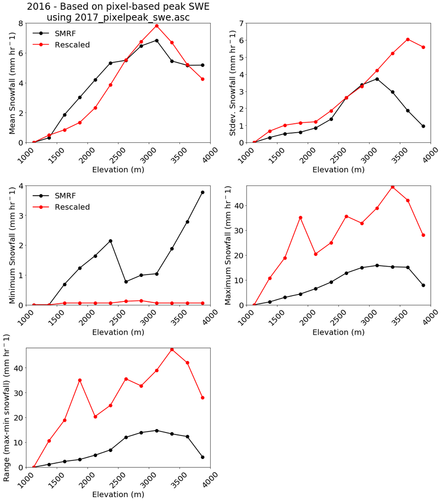

```python
fs_axes = 20
fs_title = 24
fs_labels = 20
fs_legend = 20

# Plot 1 *******************************************************
# Full domain
# print('The folowing plots, points aligned along the 1-1 line imply that\n mass is being conserved using the rescaling interpolation scheme')

# Mean  ------------------------------------------------
plt.figure(figsize = (16, 18))
ax1 = plt.subplot(3, 2, 1)

# x_max = max(stats_test.max(axis = 0)['sum_precip_smrf'], stats_test.max(axis = 0)['sum_precip_rescaled']) * 50 * 50 * 1e-3 # should be in m3

smrf_series = snowfall_tuolumne_elev_comparison['mean_smrf']
rescaled_series = snowfall_tuolumne_elev_comparison['mean_rescaled']
y_max = max(smrf_series.max(), rescaled_series.max()).astype(int)+1

h_smrf = plt.plot(snowfall_tuolumne_elev_comparison.index.values + band_width/2, smrf_series,
                  '-k', linewidth = 2, zorder = 0, label = 'SMRF')
h_rescaled = plt.plot(snowfall_tuolumne_elev_comparison.index.values + band_width/2, rescaled_series,
                      '-r', linewidth = 2, zorder = 0, label = 'Rescaled')
# h_scatter = plt.scatter(stats_test['sum_precip_smrf'].values * 50 * 50 * 1e-3, stats_test['sum_precip_rescaled'].values * 50 * 50 * 1e-3)
# plt.setp(h_scatter, color = 'r')
ax1.set_xlabel('Elevation (m)', fontsize = fs_labels)
ax1.set_ylabel('Mean Snowfall (mm hr$^-1$)', fontsize = fs_labels)
plt.setp(h_smrf, color = 'k', linewidth = 2, marker = 'o', markersize = 8)
plt.setp(h_rescaled, color = 'r', linewidth = 2, marker = 'o', markersize = 8)
ax1.set_title(title_plots + '\nusing ' + swe_map_title, fontsize = fs_title)

# ticks_x = np.append(snowfall_tuolumne_elev_comparison.index.values, lower_limits[-1]+band_width).astype(int)
# ticklabels_x = [str(tick_x * 1e-6) for tick_x in ticks_x]
# ax1.set_xticks(ticks_x)
# ax1.set_xticklabels(ticklabels_x)
# ax1.set_yticks(ticks_x)
# ax1.set_yticklabels(ticklabels_x)
plt.tick_params(axis='x', which='major', labelsize=fs_labels, rotation = 45)
plt.tick_params(axis='y', which='major', labelsize=fs_labels)

ax1.set_xlim([lower_limits[0], lower_limits[-1]+band_width])
ax1.set_ylim([0, y_max])
# ax1.set_aspect('equal', 'box')
plt.tight_layout()

plt.rc('legend', fontsize = fs_legend, frameon=False)
ax1.legend()

# Stdev  ---------------------------------------------------------
ax2 = plt.subplot(3, 2, 2)

smrf_series = snowfall_tuolumne_elev_comparison['stdev_smrf']
rescaled_series = snowfall_tuolumne_elev_comparison['stdev_rescaled']
y_max = max(smrf_series.max(), rescaled_series.max()).astype(int)+1

h_smrf = plt.plot(snowfall_tuolumne_elev_comparison.index.values + band_width/2, smrf_series,
                  '-k', linewidth = 2, zorder = 0, label = 'SMRF')
h_rescaled = plt.plot(snowfall_tuolumne_elev_comparison.index.values + band_width/2, rescaled_series,
                      '-r', linewidth = 2, zorder = 0, label = 'Rescaled')
# h_scatter = plt.scatter(stats_test['sum_precip_smrf'].values * 50 * 50 * 1e-3, stats_test['sum_precip_rescaled'].values * 50 * 50 * 1e-3)
plt.setp(h_smrf, color = 'k', linewidth = 2, marker = 'o', markersize = 8)
plt.setp(h_rescaled, color = 'r', linewidth = 2, marker = 'o', markersize = 8)
ax2.set_xlabel('Elevation (m)', fontsize = fs_labels)
ax2.set_ylabel('Stdev. Snowfall (mm hr$^-1$)', fontsize = fs_labels)
# ax2.set_title(title_plots + '\nusing ' + swe_map_title, fontsize = fs_title)

# ticks_x = np.append(snowfall_tuolumne_elev_comparison.index.values, lower_limits[-1]+band_width).astype(int)
# ticklabels_x = [str(tick_x * 1e-6) for tick_x in ticks_x]
# ax1.set_xticks(ticks_x)
# ax1.set_xticklabels(ticklabels_x)
# ax1.set_yticks(ticks_x)
# ax1.set_yticklabels(ticklabels_x)
plt.tick_params(axis='x', which='major', labelsize=fs_labels, rotation = 45)
plt.tick_params(axis='y', which='major', labelsize=fs_labels)

ax2.set_xlim([lower_limits[0], lower_limits[-1]+band_width])
ax2.set_ylim([0, y_max])
# ax1.set_aspect('equal', 'box')
plt.tight_layout()

# min  ------------------------------------------------
ax3 = plt.subplot(3, 2, 3)

# x_max = max(stats_test.max(axis = 0)['sum_precip_smrf'], stats_test.max(axis = 0)['sum_precip_rescaled']) * 50 * 50 * 1e-3 # should be in m3

smrf_series = snowfall_tuolumne_elev_comparison['min_smrf']
rescaled_series = snowfall_tuolumne_elev_comparison['min_rescaled']
y_max = max(smrf_series.max(), rescaled_series.max()).astype(int)+1

h_smrf = plt.plot(snowfall_tuolumne_elev_comparison.index.values + band_width/2, smrf_series,
                  '-k', linewidth = 2, zorder = 0, label = 'SMRF')
h_rescaled = plt.plot(snowfall_tuolumne_elev_comparison.index.values + band_width/2, rescaled_series,
                      '-r', linewidth = 2, zorder = 0, label = 'Rescaled')
# h_scatter = plt.scatter(stats_test['sum_precip_smrf'].values * 50 * 50 * 1e-3, stats_test['sum_precip_rescaled'].values * 50 * 50 * 1e-3)
# plt.setp(h_scatter, color = 'r')
ax3.set_xlabel('Elevation (m)', fontsize = fs_labels)
ax3.set_ylabel('Minimum Snowfall (mm hr$^-1$)', fontsize = fs_labels)
plt.setp(h_smrf, color = 'k', linewidth = 2, marker = 'o', markersize = 8)
plt.setp(h_rescaled, color = 'r', linewidth = 2, marker = 'o', markersize = 8)
# ax3.set_title(title_plots + '\nusing ' + swe_map_title, fontsize = fs_title)

# ticks_x = np.append(snowfall_tuolumne_elev_comparison.index.values, lower_limits[-1]+band_width).astype(int)
# ticklabels_x = [str(tick_x * 1e-6) for tick_x in ticks_x]
# ax1.set_xticks(ticks_x)
# ax1.set_xticklabels(ticklabels_x)
# ax1.set_yticks(ticks_x)
# ax1.set_yticklabels(ticklabels_x)
plt.tick_params(axis='x', which='major', labelsize=fs_labels, rotation = 45)
plt.tick_params(axis='y', which='major', labelsize=fs_labels)

ax3.set_xlim([lower_limits[0], lower_limits[-1]+band_width])
ax3.set_ylim([0, y_max])
# ax1.set_aspect('equal', 'box')
plt.tight_layout()

plt.rc('legend', fontsize = fs_legend, frameon=False)
ax3.legend()

# Max  ---------------------------------------------------------
ax4 = plt.subplot(3, 2, 4)

smrf_series = snowfall_tuolumne_elev_comparison['max_smrf']
rescaled_series = snowfall_tuolumne_elev_comparison['max_rescaled']
y_max = max(smrf_series.max(), rescaled_series.max()).astype(int)+1

h_smrf = plt.plot(snowfall_tuolumne_elev_comparison.index.values + band_width/2, smrf_series,
                  '-k', linewidth = 2, zorder = 0, label = 'SMRF')
h_rescaled = plt.plot(snowfall_tuolumne_elev_comparison.index.values + band_width/2, rescaled_series,
                      '-r', linewidth = 2, zorder = 0, label = 'Rescaled')
# h_scatter = plt.scatter(stats_test['sum_precip_smrf'].values * 50 * 50 * 1e-3, stats_test['sum_precip_rescaled'].values * 50 * 50 * 1e-3)
plt.setp(h_smrf, color = 'k', linewidth = 2, marker = 'o', markersize = 8)
plt.setp(h_rescaled, color = 'r', linewidth = 2, marker = 'o', markersize = 8)
ax4.set_xlabel('Elevation (m)', fontsize = fs_labels)
ax4.set_ylabel('Maximum Snowfall (mm hr$^-1$)', fontsize = fs_labels)
# ax2.set_title(title_plots + '\nusing ' + swe_map_title, fontsize = fs_title)

# ticks_x = np.append(snowfall_tuolumne_elev_comparison.index.values, lower_limits[-1]+band_width).astype(int)
# ticklabels_x = [str(tick_x * 1e-6) for tick_x in ticks_x]
# ax1.set_xticks(ticks_x)
# ax1.set_xticklabels(ticklabels_x)
# ax1.set_yticks(ticks_x)
# ax1.set_yticklabels(ticklabels_x)
plt.tick_params(axis='x', which='major', labelsize=fs_labels, rotation = 45)
plt.tick_params(axis='y', which='major', labelsize=fs_labels)

ax4.set_xlim([lower_limits[0], lower_limits[-1]+band_width])
ax4.set_ylim([0, y_max])
# ax1.set_aspect('equal', 'box')
plt.tight_layout()

# Max  ---------------------------------------------------------
ax5 = plt.subplot(3, 2, 5)

smrf_series = snowfall_tuolumne_elev_comparison['range_smrf']
rescaled_series = snowfall_tuolumne_elev_comparison['range_rescaled']
y_max = max(smrf_series.max(), rescaled_series.max()).astype(int)+1

h_smrf = plt.plot(snowfall_tuolumne_elev_comparison.index.values + band_width/2, smrf_series,
                  '-k', linewidth = 2, zorder = 0, label = 'SMRF')
h_rescaled = plt.plot(snowfall_tuolumne_elev_comparison.index.values + band_width/2, rescaled_series,
                      '-r', linewidth = 2, zorder = 0, label = 'Rescaled')
# h_scatter = plt.scatter(stats_test['sum_precip_smrf'].values * 50 * 50 * 1e-3, stats_test['sum_precip_rescaled'].values * 50 * 50 * 1e-3)
plt.setp(h_smrf, color = 'k', linewidth = 2, marker = 'o', markersize = 8)
plt.setp(h_rescaled, color = 'r', linewidth = 2, marker = 'o', markersize = 8)
ax5.set_xlabel('Elevation (m)', fontsize = fs_labels)
ax5.set_ylabel('Range (max-min snowfall) (mm hr$^-1$)', fontsize = fs_labels)
# ax2.set_title(title_plots + '\nusing ' + swe_map_title, fontsize = fs_title)

# ticks_x = np.append(snowfall_tuolumne_elev_comparison.index.values, lower_limits[-1]+band_width).astype(int)
# ticklabels_x = [str(tick_x * 1e-6) for tick_x in ticks_x]
# ax1.set_xticks(ticks_x)
# ax1.set_xticklabels(ticklabels_x)
# ax1.set_yticks(ticks_x)
# ax1.set_yticklabels(ticklabels_x)
plt.tick_params(axis='x', which='major', labelsize=fs_labels, rotation = 45)
plt.tick_params(axis='y', which='major', labelsize=fs_labels)

ax5.set_xlim([lower_limits[0], lower_limits[-1]+band_width])
ax5.set_ylim([0, y_max])
# ax1.set_aspect('equal', 'box')
plt.tight_layout()


plt.show()
```

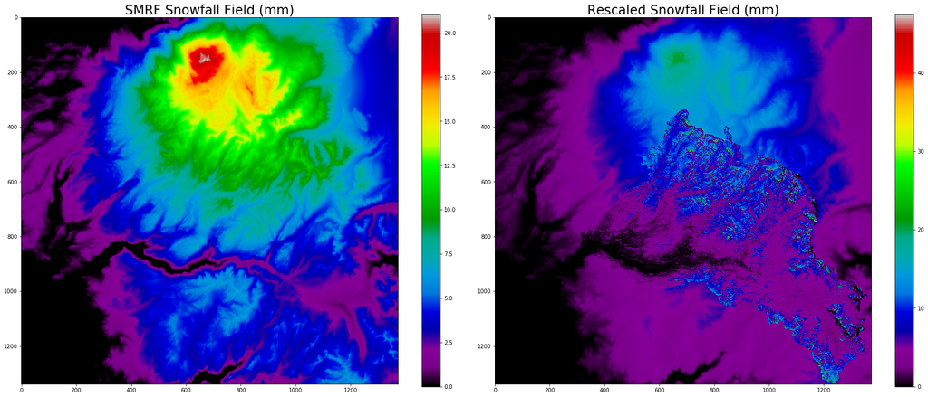

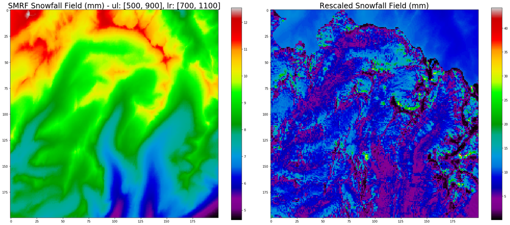

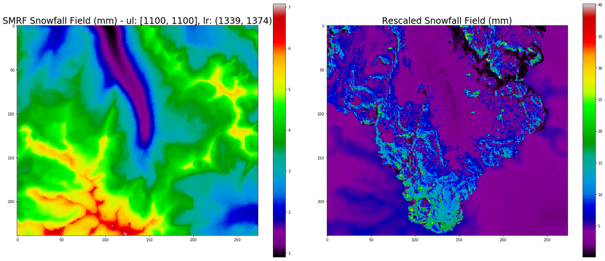

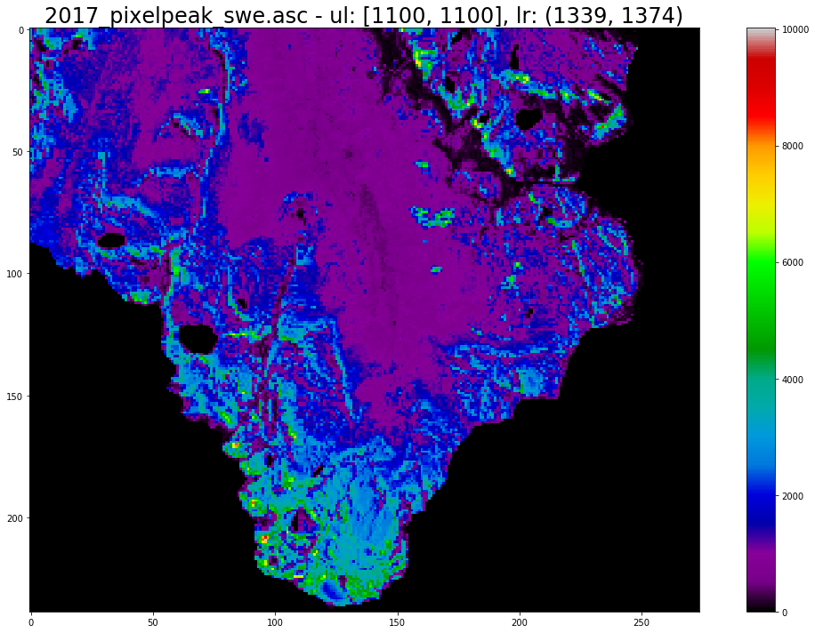

```python
fs_title = 24

# ---------------------------------------------------------------
plt.figure(figsize = (25,10))

ax1 = plt.subplot(1, 2, 1)
plt.imshow(snowfall_smrf_aux, cmap='nipy_spectral')
plt.colorbar()
plt.title('SMRF Snowfall Field (mm)', fontsize = fs_title)

ax2 = plt.subplot(1, 2, 2)
plt.imshow(snowfall_rescaled_aux, cmap='nipy_spectral')
plt.colorbar()
plt.title('Rescaled Snowfall Field (mm)', fontsize = fs_title)

plt.tight_layout()
plt.show()

# ---------------------------------------------------------------
plt.figure(figsize = (25,10))
ul = [500, 900]
lr = [700, 1100]

ax1 = plt.subplot(1, 2, 1)
plt.imshow(snowfall_smrf_aux[ul[0]:lr[0], ul[1]:lr[1]], cmap='nipy_spectral')
plt.colorbar()
plt.title('SMRF Snowfall Field (mm)' + ' - ' + 'ul: ' + str(ul) + ', lr: ' + str(lr), fontsize = fs_title)

ax2 = plt.subplot(1, 2, 2)
plt.imshow(snowfall_rescaled_aux[ul[0]:lr[0], ul[1]:lr[1]], cmap='nipy_spectral')
plt.colorbar()
plt.title('Rescaled Snowfall Field (mm)', fontsize = fs_title)

plt.tight_layout()
plt.show()

# ---------------------------------------------------------------
plt.figure(figsize = (25,10))
ul = [1100, 1100]
lr = np.shape(snowfall_smrf_aux)

ax1 = plt.subplot(1, 2, 1)
plt.imshow(snowfall_smrf_aux[ul[0]:lr[0], ul[1]:lr[1]], cmap='nipy_spectral')
plt.colorbar()
plt.title('SMRF Snowfall Field (mm)' + ' - ' + 'ul: ' + str(ul) + ', lr: ' + str(lr), fontsize = fs_title)

ax2 = plt.subplot(1, 2, 2)
plt.imshow(snowfall_rescaled_aux[ul[0]:lr[0], ul[1]:lr[1]], cmap='nipy_spectral')
plt.colorbar()
plt.title('Rescaled Snowfall Field (mm)', fontsize = fs_title)

plt.tight_layout()
plt.show()

# ---------------------------------------------------------------
plt.figure(figsize = (15,10))
ul = [1100, 1100]
lr = np.shape(snowfall_smrf_aux)

# ax1 = plt.subplot(1, 2, 1)
plt.imshow(peak_swe_map_test[ul[0]:lr[0], ul[1]:lr[1]], cmap='nipy_spectral')
plt.colorbar()
plt.title(swe_map_title + ' - ' + 'ul: ' + str(ul) + ', lr: ' + str(lr), fontsize = fs_title)

plt.tight_layout()
plt.show()
```